# Ejemplo:

Estudio sobre la percepción del color Ekman

```r
library(smacof)
library(MASS)

data(ekman)

# Estos datos en realidad corresponden a la similaridad que mencionamos en la teórica escalados
ekman = as.matrix(ekman)
ekman
```

A matrix: 14 × 14 of type dbl

|  | 434 | 445 | 465 | 472 | 490 | 504 | 537 | 555 | 584 | 600 | 610 | 628 | 651 | 674 |
| --- | --- | --- | --- | --- | --- | --- | --- | --- | --- | --- | --- | --- | --- | --- |
| 434 | 0.00 | 0.86 | 0.42 | 0.42 | 0.18 | 0.06 | 0.07 | 0.04 | 0.02 | 0.07 | 0.09 | 0.12 | 0.13 | 0.16 |
| 445 | 0.86 | 0.00 | 0.50 | 0.44 | 0.22 | 0.09 | 0.07 | 0.07 | 0.02 | 0.04 | 0.07 | 0.11 | 0.13 | 0.14 |
| 465 | 0.42 | 0.50 | 0.00 | 0.81 | 0.47 | 0.17 | 0.10 | 0.08 | 0.02 | 0.01 | 0.02 | 0.01 | 0.05 | 0.03 |
| 472 | 0.42 | 0.44 | 0.81 | 0.00 | 0.54 | 0.25 | 0.10 | 0.09 | 0.02 | 0.01 | 0.00 | 0.01 | 0.02 | 0.04 |
| 490 | 0.18 | 0.22 | 0.47 | 0.54 | 0.00 | 0.61 | 0.31 | 0.26 | 0.07 | 0.02 | 0.02 | 0.01 | 0.02 | 0.00 |
| 504 | 0.06 | 0.09 | 0.17 | 0.25 | 0.61 | 0.00 | 0.62 | 0.45 | 0.14 | 0.08 | 0.02 | 0.02 | 0.02 | 0.01 |
| 537 | 0.07 | 0.07 | 0.10 | 0.10 | 0.31 | 0.62 | 0.00 | 0.73 | 0.22 | 0.14 | 0.05 | 0.02 | 0.02 | 0.00 |
| 555 | 0.04 | 0.07 | 0.08 | 0.09 | 0.26 | 0.45 | 0.73 | 0.00 | 0.33 | 0.19 | 0.04 | 0.03 | 0.02 | 0.02 |
| 584 | 0.02 | 0.02 | 0.02 | 0.02 | 0.07 | 0.14 | 0.22 | 0.33 | 0.00 | 0.58 | 0.37 | 0.27 | 0.20 | 0.23 |
| 600 | 0.07 | 0.04 | 0.01 | 0.01 | 0.02 | 0.08 | 0.14 | 0.19 | 0.58 | 0.00 | 0.74 | 0.50 | 0.41 | 0.28 |
| 610 | 0.09 | 0.07 | 0.02 | 0.00 | 0.02 | 0.02 | 0.05 | 0.04 | 0.37 | 0.74 | 0.00 | 0.76 | 0.62 | 0.55 |
| 628 | 0.12 | 0.11 | 0.01 | 0.01 | 0.01 | 0.02 | 0.02 | 0.03 | 0.27 | 0.50 | 0.76 | 0.00 | 0.85 | 0.68 |
| 651 | 0.13 | 0.13 | 0.05 | 0.02 | 0.02 | 0.02 | 0.02 | 0.02 | 0.20 | 0.41 | 0.62 | 0.85 | 0.00 | 0.76 |
| 674 | 0.16 | 0.14 | 0.03 | 0.04 | 0.00 | 0.01 | 0.00 | 0.02 | 0.23 | 0.28 | 0.55 | 0.68 | 0.76 | 0.00 |

A matrix: 14 × 2 of type dbl

| 434 | -0.1848053 | -0.32826594 |
| --- | --- | --- |
| 445 | -0.2215432 | -0.32209210 |
| 465 | -0.3562565 | -0.24256440 |
| 472 | -0.3778483 | -0.21386512 |
| 490 | -0.3794929 | 0.05897124 |
| 504 | -0.2909680 | 0.29226246 |
| 537 | -0.2101235 | 0.37441167 |
| 555 | -0.1637029 | 0.38296896 |
| 584 | 0.2091014 | 0.23325487 |
| 600 | 0.3473492 | 0.11984342 |
| 610 | 0.4311815 | -0.02244233 |
| 628 | 0.4286262 | -0.08223907 |
| 651 | 0.3962484 | -0.11609737 |
| 674 | 0.3722340 | -0.13414629 |

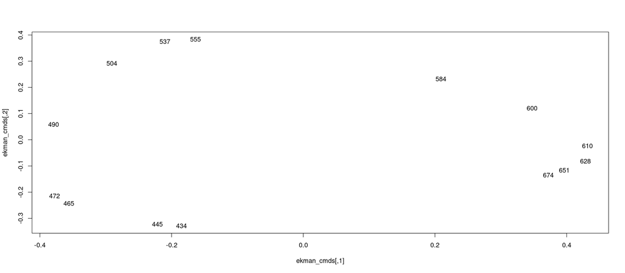

```r
# Utilizamos el cmds

ekman_cmds = cmdscale(1-ekman, k=2)

options(repr.plot.width = 16)
plot(ekman_cmds, type="n")
text(ekman_cmds, labels=rownames(ekman))

ekman_cmds
```

```
Initial stress        : 0.12463
stress after  10 iters: 0.02246, magic = 0.500
stress after  20 iters: 0.02225, magic = 0.500
stress after  30 iters: 0.02224, magic = 0.500
```

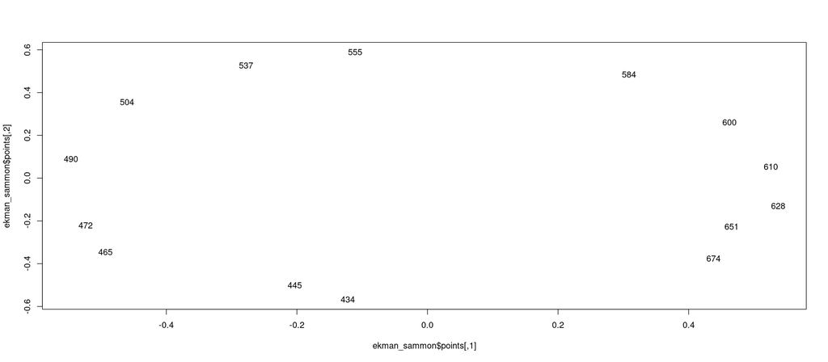

```r
# Sammon

ekman_sammon = sammon(1-ekman, k = 2)

plot(ekman_sammon$points,type="n")
text(ekman_sammon$points, labels=rownames(ekman))
```

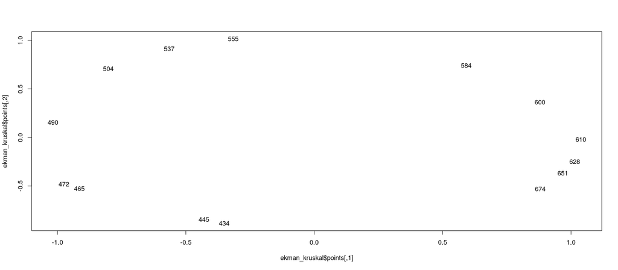

```r
# Kruskal

ekman_kruskal = isoMDS(1-ekman,k=2)

plot(ekman_kruskal$points, type="n")
text(ekman_kruskal$points, labels=rownames(ekman))
```

### Ejercicio 1:

El conjunto de datos "eurodist" de la libreria MASS contiene las distancias (medidas en ruta en km) entre 21 ciudades europeas. Encontrar una representación bidimensional de las distancias.

### Ejercicio 2:

El conjunto de datos "swiss" contiene mediciones de fertilidad e indicadores socio-económicos de 47 provincias suizas del año 1888. Utilizas la técnica de multidimensional scaling para poder tener una representación visual. ¿Qué observa?

### Ejercicio 3:

Wolford and Hollingsworth (1974) llevaron adelante un estudio para comprender las confunsiones que las personas tienen cuando intentan identificar letras del alfabeto que se muestran durante algunos milisegundos. Se construyó una matriz de confunsión que se encuentra en el archivo *letters.csv*. La matriz contiene las frecuencias con las cuales las letras fueron confundidads.

1- ¿Por qué no puede considerarse una disimilaridad a la matriz de confusión?

2- Construir la disimilaridad a partir de la similaridad.

*Sugerencia* considerar un número $c> \max(s_{ij})$ donde $(s_{ij})_{ij}$ es la matriz de disimilaridad. Luego tomar $d_{ij} = c - s_{ij}.$

3- Comparar los resultados que devuelven los algoritmos para $c=21$ y $c=210.$

4- ¿Cuál resulta más adecuado en este caso?¿Por qué?